# Modulo 7 - Seconda serie

Soluzioni

Author

Ottavia Epifania

# 1 Il dataset

Il dataset si chiama `regressione-completa.csv` e contiene i dati di 300 persone. Lo studio indaga l’ansia e alcune variabili che possono essere collegate a essa: la flessibilità cognitiva, la pratica quotidiana di mindfulness e l’attività sportiva praticata.

Il file usa la virgola come separatore e il punto come separatore decimale, quindi va importato con `read.csv()`.

Sono presenti le seguenti variabili:

- `ansia`: punteggio di ansia, più è alto il punteggio maggiore è l’ansia
- `flessibilita`: punteggio di flessibilità cognitiva, più è alto il punteggio maggiore è la flessibilità
- `mindfulness`: pratica quotidiana di mindfulness, `no` o `sì`
- `attivita`: tipo di attività sportiva praticata, `altro`, `pilates` o `yoga`

# 2 Esercizi

Tutte le analisi devono essere precedute dalle opportune rappresentazioni grafiche.

Lo scopo dell’indagine è studiare la relazione tra flessibilità cognitiva e ansia, considerando anche l’effetto di altre variabili categoriali (la pratica di mindfulness e il tipo di attività).

## 2.1

Importare il dataset e assegnarlo alla variabile `data`.

```r
data = read.csv("regressione-completa.csv")
head(data)
```

```
     ansia flessibilita mindfulness attivita
1 50.17244     44.39524          no  pilates
2 31.47451     47.69823          sì    altro
3 34.03981     65.58708          no  pilates
4 37.06712     50.70508          no    altro
5 48.30549     51.29288          no    altro
6 16.94087     67.15065          sì    altro
```

```r
str(data)
```

```
'data.frame':   300 obs. of  4 variables:
 $ ansia       : num  50.2 31.5 34 37.1 48.3 ...
 $ flessibilita: num  44.4 47.7 65.6 50.7 51.3 ...
 $ mindfulness : chr  "no" "sì" "no" "no" ...
 $ attivita    : chr  "pilates" "altro" "pilates" "altro" ...
```

## 2.2

### 2.2.1

Studiare la relazione tra ansia (variabile dipendente) e flessibilità cognitiva (variabile indipendente).

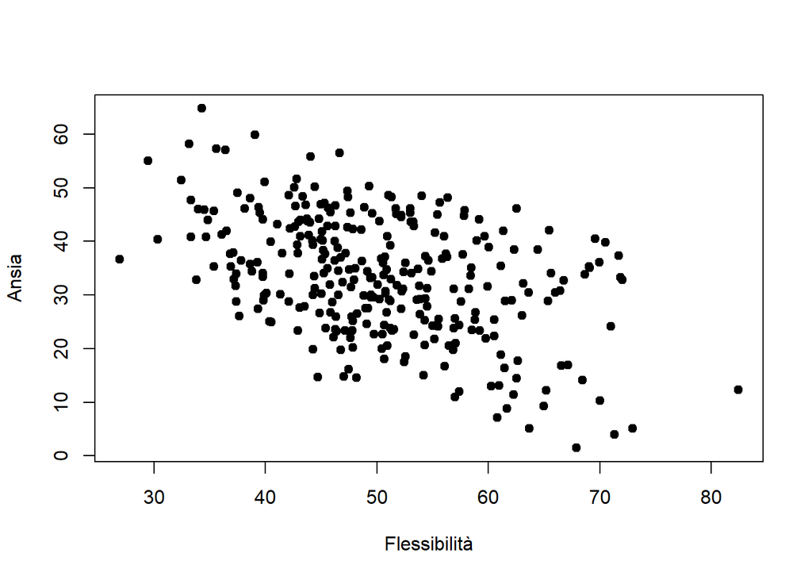

```r
plot(data$ansia ~ data$flessibilita, pch = 19,
     xlab = "Flessibilità", ylab = "Ansia")
```

```
Dal grafico si intuisce una relazione negativa
```

```r
m = lm(ansia ~ flessibilita, data = data)
summary(m)
```

```
Call:
lm(formula = ansia ~ flessibilita, data = data)

Residuals:
     Min       1Q   Median       3Q      Max
-22.5249  -7.9503   0.0537   7.6215  22.7308

Coefficients:
             Estimate Std. Error t value Pr(>|t|)
(Intercept)  60.45049    3.11204  19.425   <2e-16 ***
flessibilita -0.53695    0.06076  -8.838   <2e-16 ***
---
Signif. codes:  0 '***' 0.001 '**' 0.01 '*' 0.05 '.' 0.1 ' ' 1

Residual standard error: 9.936 on 298 degrees of freedom
Multiple R-squared:  0.2077,    Adjusted R-squared:  0.205
F-statistic: 78.11 on 1 and 298 DF,  p-value: < 2.2e-16
```

```
Entrambi i parametri del modello sono significativi. Il coefficiente
angolare negativo conferma la relazione negativa tra le variabili: all'aumentare
della flessibilità l'ansia diminuisce in media. Il modello spiega circa
il 20% della variabilità dell'ansia
```

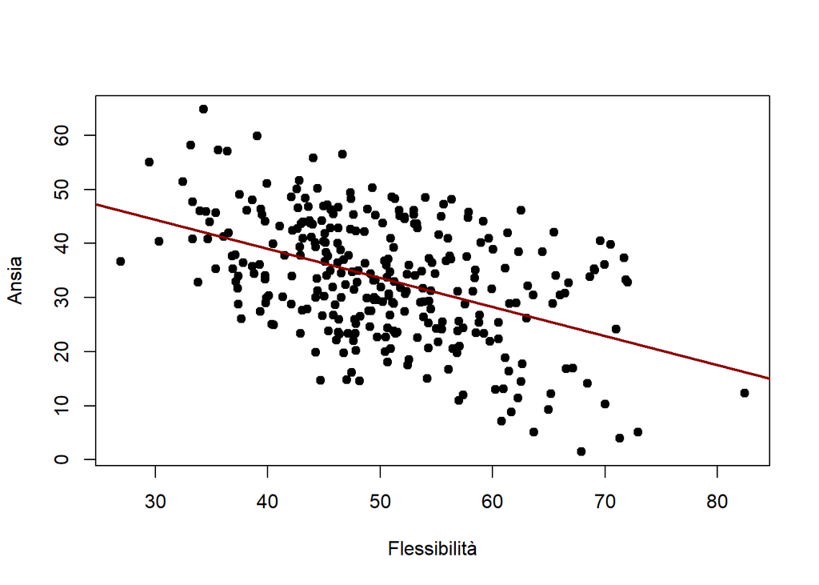

```r
plot(data$ansia ~ data$flessibilita, pch = 19,
     xlab = "Flessibilità", ylab = "Ansia")
abline(m, col = "darkred", lwd = 2)
```

### 2.2.2

Calcolare gli intervalli di confidenza al 90% per i parametri del modello.

```r
modelcoef = data.frame(summary(m)$coefficients)
qquantile90 = qt(.95, m$df.residual)
delta = qquantile90 * modelcoef$Std..Error
data.frame(limInf = modelcoef$Estimate - delta,
           limSup = modelcoef$Estimate + delta,
           row.names = rownames(modelcoef))
```

```
                 limInf     limSup
(Intercept)  55.3156840 65.5852975
flessibilita -0.6371983 -0.4367068
```

```r
# confronto con la funzione confint()
confint(m, level = .90)
```

```
                    5 %       95 %
(Intercept)  55.3156840 65.5852975
flessibilita -0.6371983 -0.4367068
```

### 2.2.3

Valutare i residui del modello con almeno due rappresentazioni grafiche.

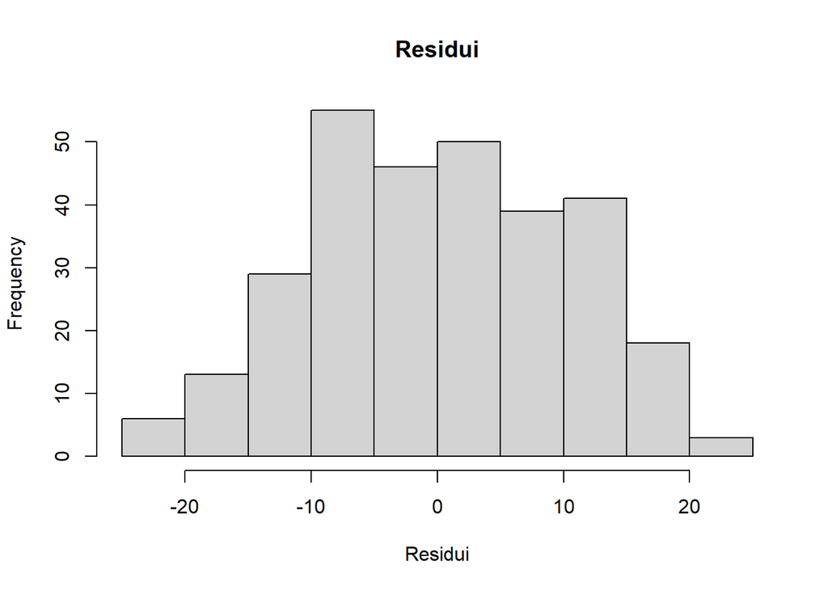

```r
hist(m$residuals, main = "Residui", xlab = "Residui")
```

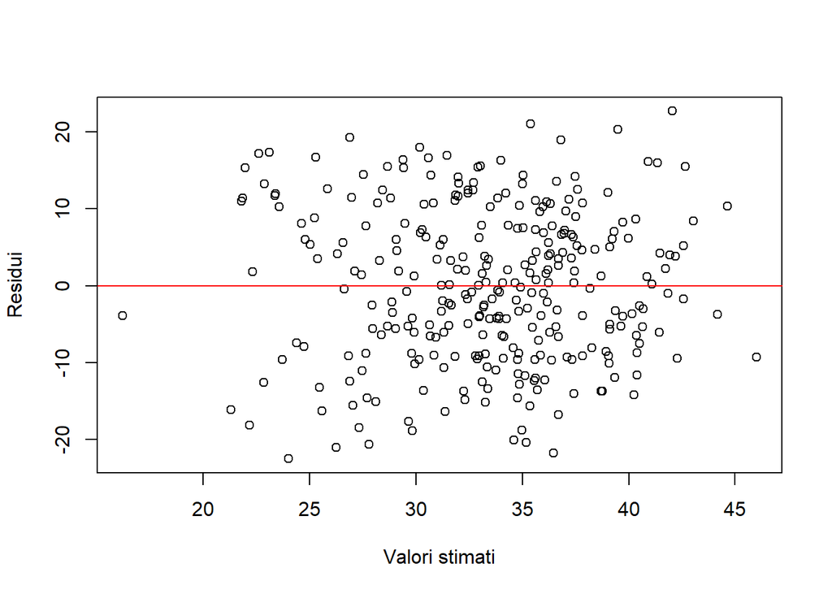

```r
plot(m$fitted.values, m$residuals,
     xlab = "Valori stimati", ylab = "Residui")
abline(h = 0, col = "red")
```

```
I residui sono centrati sullo 0 e distribuiti in modo abbastanza simmetrico.
Nel grafico residui-valori stimati non c'è un andamento lineare, ma la dispersione
è ampia: nel modello mancano variabili importanti (es. la pratica di mindfulness),
che vengono inserite nell'esercizio successivo
```

## 2.3

Studiare la relazione tra ansia e flessibilità cognitiva considerando anche la pratica di mindfulness.

### 2.3.1

Stimare il modello parallelo, ricavare le equazioni delle due rette e rappresentarle nel grafico.

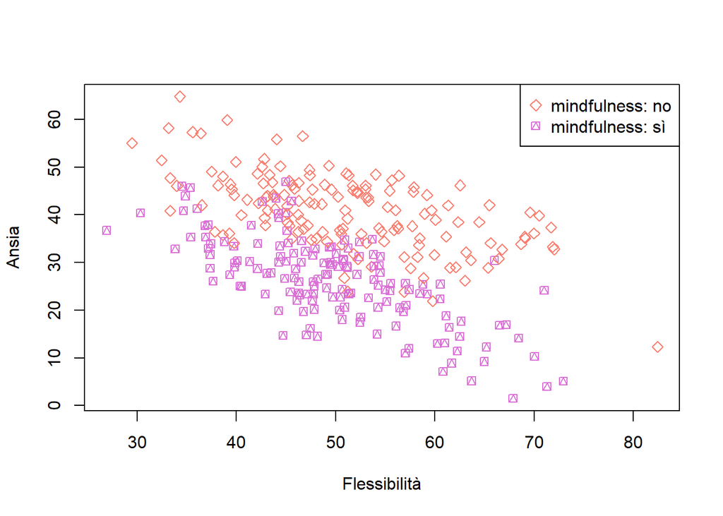

```r
plot(data$ansia ~ data$flessibilita,
     pch = ifelse(data$mindfulness == "no", 5, 14),
     col = ifelse(data$mindfulness == "no", "salmon", "orchid"),
     xlab = "Flessibilità", ylab = "Ansia")
legend("topright", pch = c(5, 14), col = c("salmon", "orchid"),
       legend = c("mindfulness: no", "mindfulness: sì"))
```

```r
mparall = lm(ansia ~ flessibilita + mindfulness, data = data)
summary(mparall)
```

```
Call:
lm(formula = ansia ~ flessibilita + mindfulness, data = data)

Residuals:
     Min       1Q   Median       3Q      Max
-16.6324  -4.6263  -0.1083   4.5178  17.8382

Coefficients:
               Estimate Std. Error t value Pr(>|t|)
(Intercept)    70.65484    2.09400   33.74   <2e-16 ***
flessibilita   -0.58912    0.03974  -14.82   <2e-16 ***
mindfulnesssì -15.05605    0.75050  -20.06   <2e-16 ***
---
Signif. codes:  0 '***' 0.001 '**' 0.01 '*' 0.05 '.' 0.1 ' ' 1

Residual standard error: 6.485 on 297 degrees of freedom
Multiple R-squared:  0.6636,    Adjusted R-squared:  0.6613
F-statistic: 292.9 on 2 and 297 DF,  p-value: < 2.2e-16
```

```
Il modello è significativo, insieme a tutti i parametri stimati.
A parità di flessibilità, chi pratica mindfulness ha in media un livello di ansia più basso.
Il modello spiega più del 60% della variabilità dell'ansia
```

```r
parallCoef = coef(mparall)
# mindfulness = no: ansia* = b0 + b1 * flessibilita
c(intercetta = parallCoef[1], pendenza = parallCoef[2])
```

```
intercetta.(Intercept)  pendenza.flessibilita
            70.6548443             -0.5891161
```

```r
# mindfulness = sì: ansia* = (b0 + b2) + b1 * flessibilita
c(intercetta = parallCoef[1] + parallCoef[3], pendenza = parallCoef[2])
```

```
intercetta.(Intercept)  pendenza.flessibilita
            55.5987980             -0.5891161
```

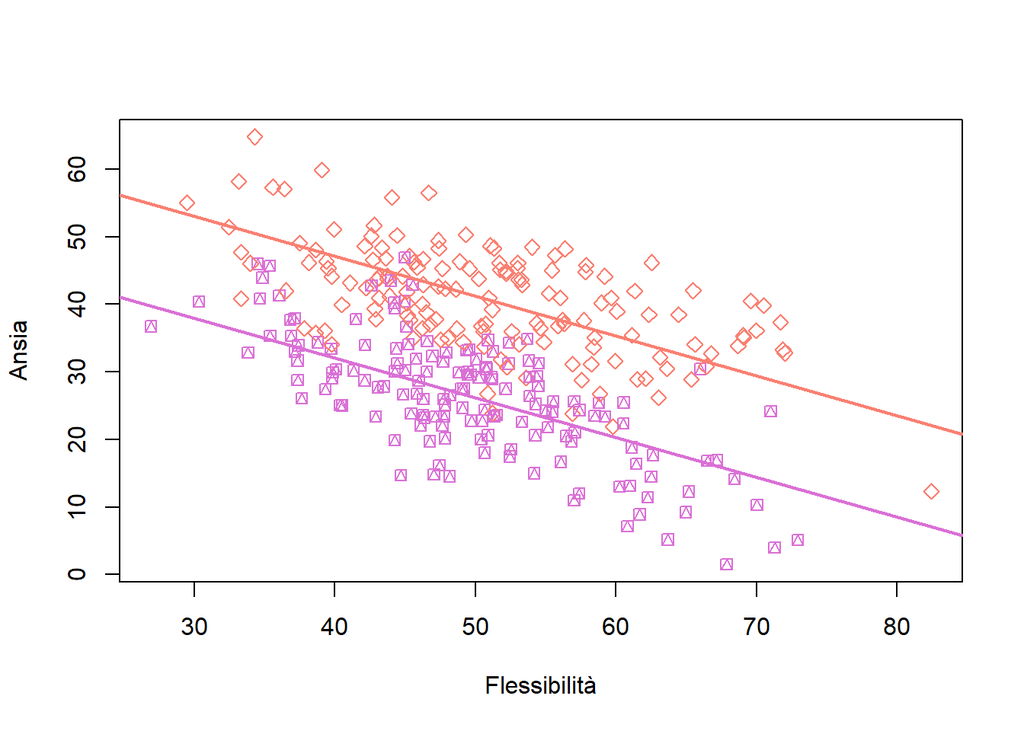

```r
plot(data$ansia ~ data$flessibilita,
     pch = ifelse(data$mindfulness == "no", 5, 14),
     col = ifelse(data$mindfulness == "no", "salmon", "orchid"),
     xlab = "Flessibilità", ylab = "Ansia")
abline(parallCoef[1], parallCoef[2], col = "salmon", lwd = 2)
abline(parallCoef[1] + parallCoef[3], parallCoef[2], col = "orchid", lwd = 2)
```

### 2.3.2

Stimare il modello con interazione, ricavare le equazioni delle due rette e rappresentarle nel grafico.

```r
minter = lm(ansia ~ flessibilita * mindfulness, data = data)
summary(minter)
```

```
Call:
lm(formula = ansia ~ flessibilita * mindfulness, data = data)

Residuals:
     Min       1Q   Median       3Q      Max
-16.6577  -4.7994   0.0147   4.1728  17.1967

Coefficients:
                           Estimate Std. Error t value Pr(>|t|)
(Intercept)                64.93513    2.75137  23.601  < 2e-16 ***
flessibilita               -0.47689    0.05300  -8.998  < 2e-16 ***
mindfulnesssì              -2.62462    4.02421  -0.652  0.51477
flessibilita:mindfulnesssì -0.24719    0.07865  -3.143  0.00184 **
---
Signif. codes:  0 '***' 0.001 '**' 0.01 '*' 0.05 '.' 0.1 ' ' 1

Residual standard error: 6.391 on 296 degrees of freedom
Multiple R-squared:  0.6744,    Adjusted R-squared:  0.6711
F-statistic: 204.4 on 3 and 296 DF,  p-value: < 2.2e-16
```

```
Il modello è significativo. Sono significativi tutti i parametri tranne
l'effetto principale della mindfulness, che rappresenta la differenza tra i gruppi
quando la flessibilità è 0. L'interazione è significativa e negativa: tra chi pratica
mindfulness la relazione negativa tra flessibilità e ansia è più forte.
Il modello spiega circa il 67% della variabilità dell'ansia
```

```r
interCoef = coef(minter)
# mindfulness = no: ansia* = b0 + b1 * flessibilita
c(intercetta = interCoef[1], pendenza = interCoef[2])
```

```
intercetta.(Intercept)  pendenza.flessibilita
            64.9351311             -0.4768907
```

```r
# mindfulness = sì: ansia* = (b0 + b2) + (b1 + b3) * flessibilita
c(intercetta = interCoef[1] + interCoef[3],
  pendenza = interCoef[2] + interCoef[4])
```

```
intercetta.(Intercept)  pendenza.flessibilita
            62.3105129             -0.7240772
```

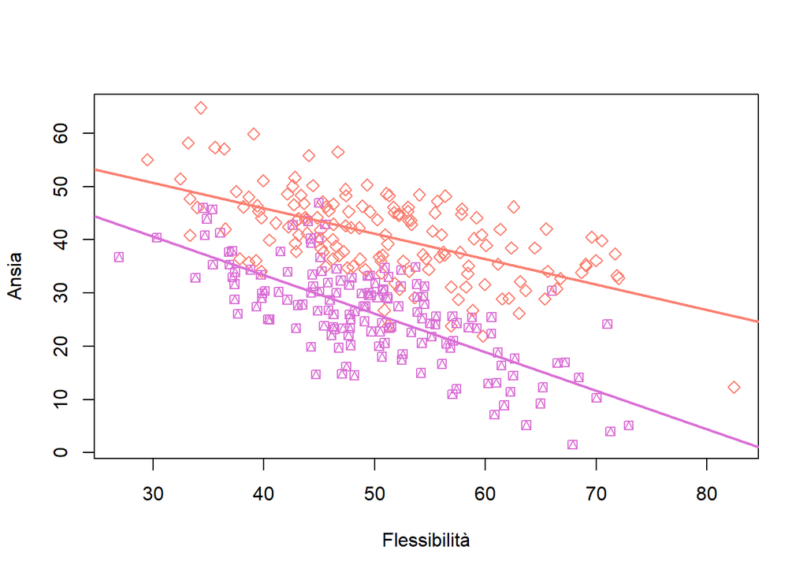

```r
plot(data$ansia ~ data$flessibilita,
     pch = ifelse(data$mindfulness == "no", 5, 14),
     col = ifelse(data$mindfulness == "no", "salmon", "orchid"),
     xlab = "Flessibilità", ylab = "Ansia")
abline(interCoef[1], interCoef[2], col = "salmon", lwd = 2)
abline(interCoef[1] + interCoef[3], interCoef[2] + interCoef[4],
       col = "orchid", lwd = 2)
```

## 2.4

### 2.4.1

Selezionare solo i dati delle persone che praticano yoga e assegnare il nuovo dataset alla variabile `d1`.

```r
d1 = data[data$attivita == "yoga", ]
nrow(d1)
```

```
[1] 117
```

### 2.4.2

Studiare la relazione tra ansia e flessibilità cognitiva su questo sottocampione.

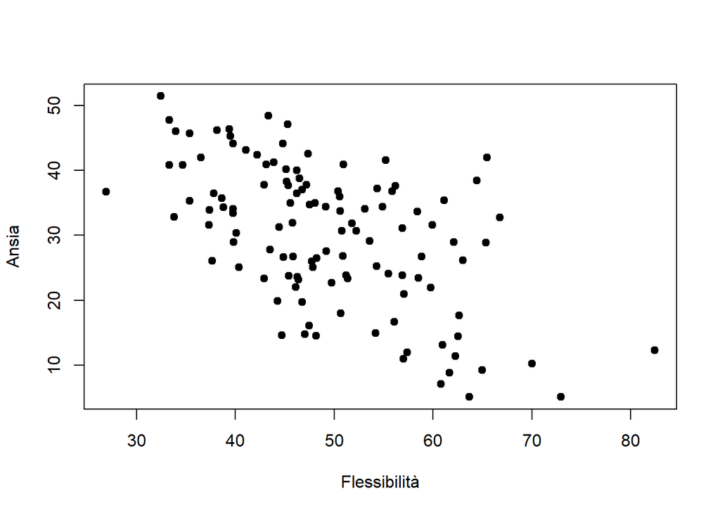

```r
plot(ansia ~ flessibilita, data = d1, pch = 19,
     xlab = "Flessibilità", ylab = "Ansia")
```

```r
myoga = lm(ansia ~ flessibilita, data = d1)
summary(myoga)
```

```
Call:
lm(formula = ansia ~ flessibilita, data = d1)

Residuals:
     Min       1Q   Median       3Q      Max
-18.3189  -7.0016  -0.3409   6.9996  22.1942

Coefficients:
             Estimate Std. Error t value Pr(>|t|)
(Intercept)  61.25467    4.24317  14.436  < 2e-16 ***
flessibilita -0.63262    0.08452  -7.485 1.57e-11 ***
---
Signif. codes:  0 '***' 0.001 '**' 0.01 '*' 0.05 '.' 0.1 ' ' 1

Residual standard error: 8.869 on 115 degrees of freedom
Multiple R-squared:  0.3276,    Adjusted R-squared:  0.3217
F-statistic: 56.02 on 1 and 115 DF,  p-value: 1.568e-11
```

```
Anche tra chi pratica yoga la relazione tra flessibilità e ansia è negativa
e significativa
```

## 2.5

Le analisi seguenti vanno effettuate sull’intero campione.

### 2.5.1

Il livello medio di ansia è diverso a seconda del tipo di attività sportiva praticata? Rappresentare graficamente i dati, stimare il modello di regressione con `attivita` come unico predittore e commentare sia i test sui singoli coefficienti sia il test sul fattore nel suo complesso.

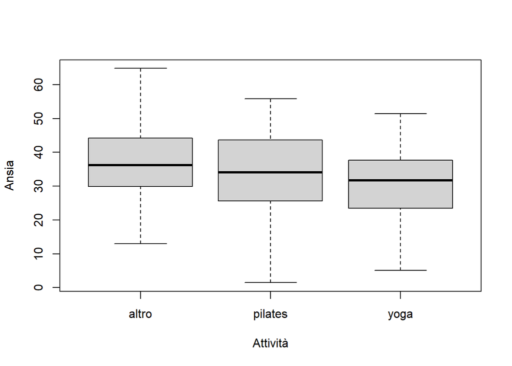

```r
boxplot(ansia ~ attivita, data = data,
        xlab = "Attività", ylab = "Ansia")
```

```r
tapply(data$ansia, data$attivita, mean)
```

```
   altro  pilates     yoga
37.05977 33.79411 30.09420
```

```r
matt = lm(ansia ~ attivita, data = data)
summary(matt)
```

```
Call:
lm(formula = ansia ~ attivita, data = data)

Residuals:
    Min      1Q  Median      3Q     Max
-32.311  -6.941   0.605   7.826  27.716

Coefficients:
                Estimate Std. Error t value Pr(>|t|)
(Intercept)       37.060      1.089  34.026  < 2e-16 ***
attivitapilates   -3.266      1.598  -2.043   0.0419 *
attivitayoga      -6.966      1.476  -4.718 3.67e-06 ***
---
Signif. codes:  0 '***' 0.001 '**' 0.01 '*' 0.05 '.' 0.1 ' ' 1

Residual standard error: 10.78 on 297 degrees of freedom
Multiple R-squared:  0.07014,   Adjusted R-squared:  0.06388
F-statistic:  11.2 on 2 and 297 DF,  p-value: 2.042e-05
```

```r
anova(matt)
```

```
Analysis of Variance Table

Response: ansia
           Df Sum Sq Mean Sq F value    Pr(>F)
attivita    2   2604 1302.16  11.201 2.042e-05 ***
Residuals 297  34527  116.25
---
Signif. codes:  0 '***' 0.001 '**' 0.01 '*' 0.05 '.' 0.1 ' ' 1
```

```
Il gruppo di riferimento è 'altro' (primo livello in ordine alfabetico).
L'intercetta è la media dell'ansia nel gruppo 'altro'.
I coefficienti di pilates e yoga sono le differenze tra le medie di questi gruppi
e la media del gruppo 'altro': entrambi sono negativi e significativi.
Il test F (anche nella tabella dell'ANOVA) è significativo:
almeno una media è diversa dalle altre.
Il modello spiega però solo il 7% circa della variabilità dell'ansia
```

### 2.5.2

L’ansia media di chi pratica pilates è diversa da quella di chi pratica yoga? Cambiare il gruppo di riferimento per rispondere alla domanda.

```r
data$attivitaPilates = factor(data$attivita,
                              levels = c("pilates", "altro", "yoga"))
mattPilates = lm(ansia ~ attivitaPilates, data = data)
summary(mattPilates)
```

```
Call:
lm(formula = ansia ~ attivitaPilates, data = data)

Residuals:
    Min      1Q  Median      3Q     Max
-32.311  -6.941   0.605   7.826  27.716

Coefficients:
                     Estimate Std. Error t value Pr(>|t|)
(Intercept)            33.794      1.169  28.897   <2e-16 ***
attivitaPilatesaltro    3.266      1.598   2.043   0.0419 *
attivitaPilatesyoga    -3.700      1.537  -2.408   0.0167 *
---
Signif. codes:  0 '***' 0.001 '**' 0.01 '*' 0.05 '.' 0.1 ' ' 1

Residual standard error: 10.78 on 297 degrees of freedom
Multiple R-squared:  0.07014,   Adjusted R-squared:  0.06388
F-statistic:  11.2 on 2 and 297 DF,  p-value: 2.042e-05
```

```
Ora il gruppo di riferimento è 'pilates': il coefficiente di yoga è la differenza
tra la media di yoga e quella di pilates. Il test t su questo coefficiente risponde
alla domanda. Il test F sul modello non cambia, perché il modello è lo stesso
```